# Monitoring tropical insects in the 21st century - ScienceDirect

## Outline

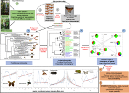

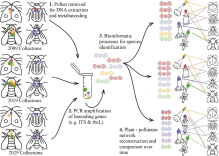

## [Advances in Ecological Research](https://www.sciencedirect.com/science/journal/00652504)

[Volume 62](https://www.sciencedirect.com/science/journal/00652504/62/supp/C), 2020, Pages 295-330

# Chapter Eight - Monitoring tropical insects in the 21st century

https://doi.org/10.1016/bs.aecr.2020.01.004[Get rights and content](https://s100.copyright.com/AppDispatchServlet?publisherName=ELS&contentID=S0065250420300040&orderBeanReset=true)

## Abstract

Research has repeatedly shown that ongoing habitat loss and the increasing frequency of extreme climatic events have altered fundamental biological processes, threatening biodiversity and ecosystem functioning worldwide. However, the multitude of interacting factors underlying the impacts of these threats remain poorly understood in tropical forests. This is unfortunate because the majority of terrestrial biodiversity resides in these habitats. The responses of organisms to environmental changes are often studied indirectly, for example, using discrete snapshots at different time periods at the same location. This is due to the challenges of compiling long-term data, especially for invertebrates. Evaluating how functionally important species assemblages will respond to anthropogenic threats requires continuous long-term monitoring. This is vital for arthropods because they are responsible for crucial ecosystem services and human food security. Here, we review existing arthropod monitoring schemes and consider some innovative avenues for future research that promise to improve monitoring of this important group in tropical systems.

## Keywords

Insect

Monitoring

Ecosystem service

Tropical forest

Climate change

Functional trait

Thermal tolerance

Network structure

Metabarcoding

Copyright © 2020 Elsevier Ltd. All rights reserved.

## Part of volume:

[Tropical Ecosystems in the 21st Century](https://www.sciencedirect.com/science/journal/00652504/62/supp/C)

Edited by

Alex J. Dumbrell, Edgar C. Turner, Tom M. Fayle